# Mini Proyecto TD 2024

Entrega final

Víctor Álvarez Palomares, Sergio Martínez Yagüe, Ferran Medina Mompó, Carles Pascual i Sivera, y Úrsula Casaus Fabra

2024-05-14

# Introducción

En esta primera parte de la entrega, vamos a importar y a analizar la información que nos aportan una serie de tickets de la compra que se nos proporcionan desde la asignatura.

## Carga de librerías y datos necesarios para el análisis

Para empezar, se cargan todas las librerías necesarias para la realización del código. Esto se hace de manera más elegante utilizando el paquete pacman de RStudio. A continuación, se realiza la carga del conjunto de datos, los cuales se encuentran en formato .pdf. No obstante, no podemos importarlos desde este formato, así que vamos a convertirlos a .txt mediante una función que hemos creado en Python con la librería PyPDF2. De esta forma, obtenemos los ficheros .txt para poder importarlos en RStudio y trabajar con ellos.

## Características generales de los datos

Los datos de los tickets se van a encontrar en listas de data frames. Cada dataframe contiene registros de 4 variables: “producto” (de tipo caracter), “unidades”, “precio_completo” y “precio_individual” (estas de tipo numérico). El número de registros depende de cada data frame, ya que el número de productos varía según la compra.

## Análisis de “missing data” en nuestro conjunto de interés

Por suerte, en nuestros conjuntos de datos no hay “missing data”, ya que se tratan de tickets de la compra en los cuales cada producto tiene un nombre y precio asignados, y los tickets contienen la cantidad de veces que se añade a la compra.

# Importación de los datos

Como ya hemos explicado previamente, hemos convertido nuestros ficheros a .txt desde .pdf. Ahora, vamos a crear otra función para separar las cadenas de caracteres de los ficheros y así importar los datos en los dataframes de forma que nos resulte más fácil trabajar con ellos. También hemos de crear un par de funciones que lean la fruta de forma correcta, pues el formato es distinto al resto de productos.

# Preguntas

A continuación vamos a plantearnos diferentes cuestiones que nos podrían venir a la cabeza a la hora de hacer un análisis de los tickets de la compra.

1. ¿Cuáles productos son los más caros?
2. ¿Qué productos se compran más?
3. ¿A qué hora del día hay más compras?
4. ¿Qué días hay más compras?
5. ¿Cuántos productos se compran de media en una compra?
6. ¿Qué productos cambian de precio (por kg)?
7. ¿Qué tipo de IVA recauda más dinero?

## 1) ¿Cuáles son los productos más caros?

Para poder obtener esta información, vamos a trabajar solo con las variables “producto” y “precio_individual”. Vamos a extraer estas columnas de los data frames y vamos a combinar toda esta información en un único data frame que ordenaremos posteriormente de forma descendente. Cuando ya tengamos la información ordenada, crearemos un gráfico que muestre los 5 productos más caros.

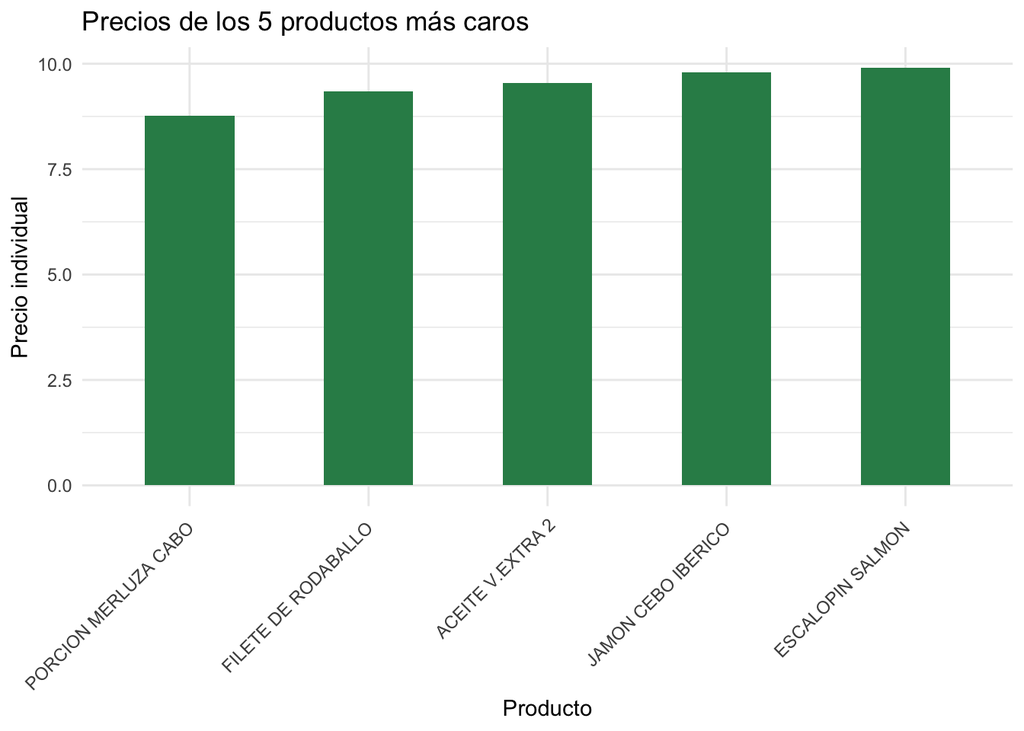

```r
# Ahora que ya tenemos la información que nos interesa ordenada, vamos a
# mostrarla con una gráfica.

# Como solo queremos mostrar los 5 primeros, los definimos en otro data frame.

df_precios_plot <- head(df_precios, 5)

grafica <- ggplot(df_precios_plot, aes(x = reorder(producto, precio_individual),
                                       y = precio_individual)) +
  geom_bar(stat = "identity", fill = "seagreen", width = 0.5) +
  labs(title = "Precios de los 5 productos más caros",
       x = "Producto",
       y = "Precio individual") +
  theme_minimal() +
  theme(axis.text.x = element_text(angle = 45, hjust = 1))

grafica
```

```r
# Si queremos descargarnos el gráfico:

# ggsave("top_5_productos_mas_caros.jpeg", grafica, width = 10, height = 6.5)
```

Como podemos observar en la gráfica, los cinco productos más caros son: el escalopín de salmón (9,90 €), el jamón de cebo ibérico (9,79 €), el aceite de oliva virgen extra (9,55 €), filete de rodaballo (9.35 €) y una porción de merluza de cabo (8,77 €). Estos resultados tienen sentido, ya que los productos mostrados son de alta calidad y de producción costosa. También podemos apreciar que se encuentran más o menos en el mismo intervalo de precio.

## 2) ¿Qué productos se compran más?

Para calcular los productos más vendidos a partir de los tickets de compra, primero vamos a contabilizar la cantidad de cada producto que se compró en cada ticket, lo que nos da un recuento de unidades para cada producto. Tras ello, sumaremos las unidades de cada producto a través de todos los tickets para obtener un total de unidades vendidas para cada producto. Finalmente, ordenamos los productos por el total de unidades vendidas para identificar los productos más vendidos. Es decir, aquellos productos con más unidades vendidas son los productos más vendidos.

```r
# Utilizamos la función que ya tenemos para obtener la lista de dataframes
lista_df <- lista

# Unimos todos los dataframes de los tickets en uno solo
todos_los_tickets <- do.call(rbind, lista_df)
# Eliminamos la última fila del dataframe
todos_los_tickets <- head(todos_los_tickets, -1)

# Convertimos la columna 'unidades' a numérica
todos_los_tickets$unidades <- as.numeric(as.character(
  todos_los_tickets$unidades))

# Eliminamos las filas con NA (que son las filas que no se pudieron convertir
#a numérico)
todos_los_tickets <- todos_los_tickets[!is.na(todos_los_tickets$unidades), ]

# A continuación, agrupamos los datos por producto y calculamos las unidades
#totales de cada producto
productos_por_unidades <- todos_los_tickets %>%
  group_by(producto) %>%
  summarise(
    unidades_total = sum(unidades),
    .groups = 'drop'
  )
# Calcula el número total de tickets
num_tickets <- length(lista_df)

# Calcula la media de unidades por ticket para cada producto
productos_por_unidades <- productos_por_unidades %>%
  mutate(unidades_promedio_por_ticket = unidades_total / num_tickets)

# Ahora, ordenamos los productos por sus unidades promedio por ticket
productos_ordenados <- productos_por_unidades %>%
  arrange(desc(unidades_promedio_por_ticket))

# Finalmente, podemos ver los productos que se compran más según la media
#de unidades por ticket
top_productos <- head(productos_ordenados)
top_productos
```

```
## # A tibble: 6 × 3
##   producto                     unidades_total unidades_promedio_por_ticket
##   <chr>                                 <dbl>                        <dbl>
## 1 "BOLSA PLASTICO 0,15 "                   32                        1.14
## 2 "CHAPATA CRISTAL 0,35 "                  15                        0.536
## 3 "ZUMO FRESCO 1L "                        15                        0.536
## 4 "LECHE DESNAT. CALCIO 0,94 "             11                        0.393
## 5 "CARACOLA AL CACAO "                     10                        0.357
## 6 "QUESO LONCHAS CABRA "                   10                        0.357
```

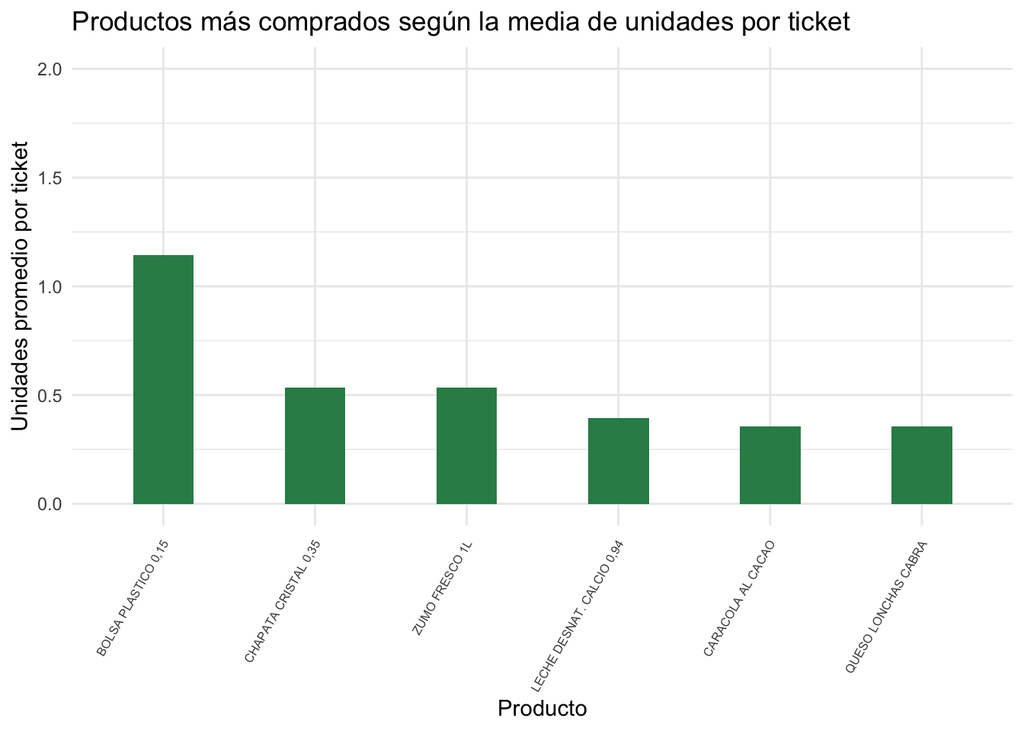

```r
# Creamos un gráfico
grafico <- ggplot(top_productos, aes(x = reorder(producto,
                                                 -unidades_promedio_por_ticket),
                                     y = unidades_promedio_por_ticket)) +
  geom_bar(stat = "identity", fill = "seagreen", width = 0.4) +
  # cambia el ancho de las barras a 0.5
  theme_minimal() + # usa un tema minimalista
  theme(axis.text.x = element_text(angle = 60, hjust = 1, size = 6)) +
  ylim(0,2) +
  labs(x = "Producto", y = "Unidades promedio por ticket",
       title = "Productos más comprados según la media de unidades por ticket")
grafico
```

```r
#Si queremos descargarnos el gráfico
#ggsave("productos_mas_comprados.jpeg", grafico, width = 10, height = 6.5)
```

Como se puede observar en la gráfica, las bolsas de plástico son el producto más vendido. Con más de 1.1 bolsas de plástico compradas por ticket. Además productos como la chaparta cristal, el zumo fresco, la leche descnatada, la caracola al cacao o el queso a lonchas de cabra también son los más vendidos entre los tickets analizados.

## 3) ¿A qué hora del día hay más compras?

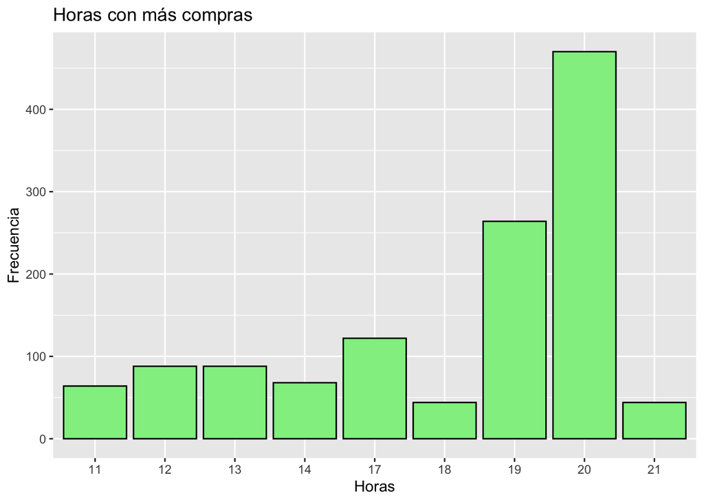

```r
# Seleccionar la columna "Horas" como factor

compras_por_hora <- tidy_ticket %>% select(Horas = Horas)

# Crear el gráfico de barras
plot <- ggplot(data = compras_por_hora, aes(x = Horas)) +
    geom_bar(fill = "lightgreen", color = "black") +
    labs(title = "Horas con más compras", x = "Horas", y = "Frecuencia")
plot
```

```r
ggsave("pregunta3.jpg", plot = plot, width = 8, height = 6, dpi = 300)
```

## 4) ¿Qué días hay más compras?

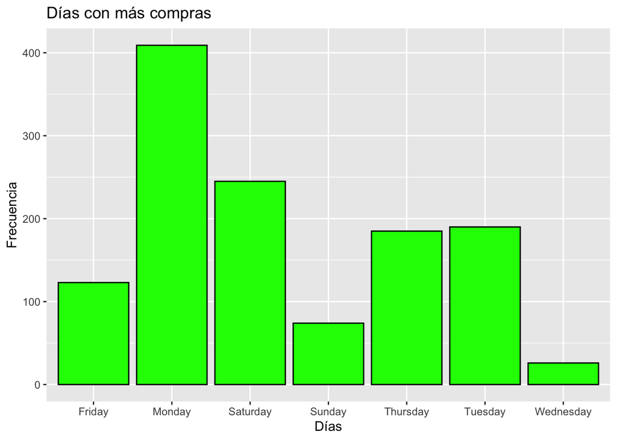

```r
compras_por_dia <- tidy_ticket %>%
  select(dia_semana = dia_semana)

# Crear el gráfico de barras
pregunta_5 <- ggplot(data = compras_por_dia, aes(x = dia_semana)) +
    geom_bar(fill = "green", color = "black") +
    labs(title = "Días con más compras", x = "Días", y = "Frecuencia")

pregunta_5
```

```r
ggsave("pregunta5.jpg", plot = pregunta_5, width = 8, height = 6, dpi = 300)
```

Como podemos observar los días con más compras son los lunes, martes y sábado, que eso nos puede demostrar que la gente va de compras a comienzo de semana y los fines de semana.